# Prosper Loan Data

## by Thomas Wiese

## Preliminary Wrangling

I'm interested in exploring defaults

```python
# import all packages and set plots to be embedded inline
import numpy as np
import pandas as pd
import matplotlib.pyplot as plt
import seaborn as sb

%matplotlib inline
```

> Load in your dataset and describe its properties through the questions below. Try and motivate your exploration goals through this section.

```python
df = pd.read_csv('prosperLoanData.csv')
pd.set_option("display.max_columns", len(df.columns))
```

```python
df.info()
```

```
<class 'pandas.core.frame.DataFrame'>
RangeIndex: 113937 entries, 0 to 113936
Data columns (total 81 columns):
ListingKey                             113937 non-null object
ListingNumber                          113937 non-null int64
ListingCreationDate                    113937 non-null object
CreditGrade                            28953 non-null object
Term                                   113937 non-null int64
LoanStatus                             113937 non-null object
ClosedDate                             55089 non-null object
BorrowerAPR                            113912 non-null float64
BorrowerRate                           113937 non-null float64
LenderYield                            113937 non-null float64
EstimatedEffectiveYield                84853 non-null float64
EstimatedLoss                          84853 non-null float64
EstimatedReturn                        84853 non-null float64
ProsperRating (numeric)                84853 non-null float64
ProsperRating (Alpha)                  84853 non-null object
ProsperScore                           84853 non-null float64
ListingCategory (numeric)              113937 non-null int64
BorrowerState                          108422 non-null object
Occupation                             110349 non-null object
EmploymentStatus                       111682 non-null object
EmploymentStatusDuration               106312 non-null float64
IsBorrowerHomeowner                    113937 non-null bool
CurrentlyInGroup                       113937 non-null bool
GroupKey                               13341 non-null object
DateCreditPulled                       113937 non-null object
CreditScoreRangeLower                  113346 non-null float64
CreditScoreRangeUpper                  113346 non-null float64
FirstRecordedCreditLine                113240 non-null object
CurrentCreditLines                     106333 non-null float64
OpenCreditLines                        106333 non-null float64
TotalCreditLinespast7years             113240 non-null float64
OpenRevolvingAccounts                  113937 non-null int64
OpenRevolvingMonthlyPayment            113937 non-null float64
InquiriesLast6Months                   113240 non-null float64
TotalInquiries                         112778 non-null float64
CurrentDelinquencies                   113240 non-null float64
AmountDelinquent                       106315 non-null float64
```

[output cut: 31 more lines]

```
LP_CustomerPayments                    113937 non-null float64
LP_CustomerPrincipalPayments           113937 non-null float64
LP_InterestandFees                     113937 non-null float64
LP_ServiceFees                         113937 non-null float64
LP_CollectionFees                      113937 non-null float64
LP_GrossPrincipalLoss                  113937 non-null float64
LP_NetPrincipalLoss                    113937 non-null float64
LP_NonPrincipalRecoverypayments        113937 non-null float64
PercentFunded                          113937 non-null float64
Recommendations                        113937 non-null int64
InvestmentFromFriendsCount             113937 non-null int64
InvestmentFromFriendsAmount            113937 non-null float64
Investors                              113937 non-null int64
dtypes: bool(3), float64(50), int64(11), object(17)
memory usage: 68.1+ MB
```

```python
df.head()
```

|  | ListingKey | ListingNumber | ListingCreationDate | CreditGrade | Term | LoanStatus | ClosedDate | BorrowerAPR | BorrowerRate | LenderYield | EstimatedEffectiveYield | EstimatedLoss | EstimatedReturn | ProsperRating (numeric) | ProsperRating (Alpha) | ProsperScore | ListingCategory (numeric) | BorrowerState | Occupation | EmploymentStatus | EmploymentStatusDuration | IsBorrowerHomeowner | CurrentlyInGroup | GroupKey | DateCreditPulled | CreditScoreRangeLower | CreditScoreRangeUpper | FirstRecordedCreditLine | CurrentCreditLines | … |
| --- | --- | --- | --- | --- | --- | --- | --- | --- | --- | --- | --- | --- | --- | --- | --- | --- | --- | --- | --- | --- | --- | --- | --- | --- | --- | --- | --- | --- | --- | --- |
| 0 | 1021339766868145413AB3B | 193129 | 2007-08-26 19:09:29.263000000 | C | 36 | Completed | 2009-08-14 00:00:00 | 0.16516 | 0.1580 | 0.1380 | NaN | NaN | NaN | NaN | NaN | NaN | 0 | CO | Other | Self-employed | 2.0 | True | True | NaN | 2007-08-26 18:41:46.780000000 | 640.0 | 659.0 | 2001-10-11 00:00:00 | 5.0 | … |
| 1 | 10273602499503308B223C1 | 1209647 | 2014-02-27 08:28:07.900000000 | NaN | 36 | Current | NaN | 0.12016 | 0.0920 | 0.0820 | 0.07960 | 0.0249 | 0.05470 | 6.0 | A | 7.0 | 2 | CO | Professional | Employed | 44.0 | False | False | NaN | 2014-02-27 08:28:14 | 680.0 | 699.0 | 1996-03-18 00:00:00 | 14.0 | … |
| 2 | 0EE9337825851032864889A | 81716 | 2007-01-05 15:00:47.090000000 | HR | 36 | Completed | 2009-12-17 00:00:00 | 0.28269 | 0.2750 | 0.2400 | NaN | NaN | NaN | NaN | NaN | NaN | 0 | GA | Other | Not available | NaN | False | True | 783C3371218786870A73D20 | 2007-01-02 14:09:10.060000000 | 480.0 | 499.0 | 2002-07-27 00:00:00 | NaN | … |
| 3 | 0EF5356002482715299901A | 658116 | 2012-10-22 11:02:35.010000000 | NaN | 36 | Current | NaN | 0.12528 | 0.0974 | 0.0874 | 0.08490 | 0.0249 | 0.06000 | 6.0 | A | 9.0 | 16 | GA | Skilled Labor | Employed | 113.0 | True | False | NaN | 2012-10-22 11:02:32 | 800.0 | 819.0 | 1983-02-28 00:00:00 | 5.0 | … |
| 4 | 0F023589499656230C5E3E2 | 909464 | 2013-09-14 18:38:39.097000000 | NaN | 36 | Current | NaN | 0.24614 | 0.2085 | 0.1985 | 0.18316 | 0.0925 | 0.09066 | 3.0 | D | 4.0 | 2 | MN | Executive | Employed | 44.0 | True | False | NaN | 2013-09-14 18:38:44 | 680.0 | 699.0 | 2004-02-20 00:00:00 | 19.0 | … |

1) Some variables have a lot of null values. TotalProsperLoans, for instance, and a lot of other variables associated with the Prosper history of the debtor.

2) A lot of these variables seem to be administrative identifiers (e.g. ListingKey and ListingNumber), and redundant ones at that. They won't be of much use to us.

3) There are 17 variables of type object. Those will probably need some attention before they're ready for some of our classification models.

4) Variables have a wide variety of ranges. We will probably need to re-scale them to make them more amenable to some of our classifiers.

*Remove same null vales first

```python
categorical = df.select_dtypes(include=["object"]).columns.values
df[categorical] = df[categorical].fillna("Unknown")

df.select_dtypes(exclude=[np.number]).isnull().sum()
```

```
ListingKey                 0
ListingCreationDate        0
CreditGrade                0
LoanStatus                 0
ClosedDate                 0
ProsperRating (Alpha)      0
BorrowerState              0
Occupation                 0
EmploymentStatus           0
IsBorrowerHomeowner        0
CurrentlyInGroup           0
GroupKey                   0
DateCreditPulled           0
FirstRecordedCreditLine    0
IncomeRange                0
IncomeVerifiable           0
LoanKey                    0
LoanOriginationDate        0
LoanOriginationQuarter     0
MemberKey                  0
dtype: int64
```

## DEAL WITH ALL THE NaN's

```python
borrower_fees = df["BorrowerAPR"] - df["BorrowerRate"]
borrower_fees.median()
```

```
0.025019999999999987
```

```python
df["BorrowerAPR"].fillna(df["BorrowerRate"] + borrower_fees.median(), inplace=True)

df["BorrowerAPR"].isnull().sum()
# fill NaN with median APR
```

```
0
```

```python
estimated_loss_from_fees = df["BorrowerRate"] - df["EstimatedEffectiveYield"]
estimated_loss_from_fees.median()
```

```
0.01915
```

```python
df["EstimatedEffectiveYield"].fillna(df["BorrowerRate"] - estimated_loss_from_fees.median(), inplace=True)

df["EstimatedEffectiveYield"].isnull().sum()
#fill NaN EFY
```

```
0
```

```python
df["EstimatedLoss"].fillna(df["EstimatedLoss"].median(), inplace=True)

df["EstimatedLoss"].isnull().sum()
# fill NaN loss
```

```
0
```

```python
df["EstimatedReturn"].fillna(df["EstimatedEffectiveYield"] - df["EstimatedLoss"], inplace=True)

df["EstimatedReturn"].isnull().sum()
# fill NaN return
```

```
0
```

```python
df["ProsperRating (numeric)"].fillna(df["ProsperRating (numeric)"].median(), inplace=True)
df["ProsperScore"].fillna(df["ProsperScore"].median(), inplace=True)


df["ProsperRating (numeric)"].isnull().sum(), df["ProsperScore"].isnull().sum()
# fill NaN rating, score
```

```
(0, 0)
```

```python
df.dropna(subset=["EmploymentStatusDuration", "CreditScoreRangeLower", "FirstRecordedCreditLine", "CurrentCreditLines",
                  "TotalCreditLinespast7years"], inplace=True)
# drop NaN
```

```python
df["DebtToIncomeRatio"].fillna(df["MonthlyLoanPayment"] / (df["StatedMonthlyIncome"] + 1), inplace = True)

df["DebtToIncomeRatio"].isnull().sum()
# fill NaN debt to income
```

```
0
```

```python
df.drop(["LoanCurrentDaysDelinquent", "LoanFirstDefaultedCycleNumber", "LoanMonthsSinceOrigination", "LP_CustomerPayments",
         "LP_CustomerPrincipalPayments", "LP_InterestandFees", "LP_ServiceFees", "LP_CollectionFees", "LP_GrossPrincipalLoss",
         "LP_NetPrincipalLoss", "LP_NonPrincipalRecoverypayments", "ListingCreationDate", "ClosedDate", "DateCreditPulled", "LoanOriginationDate", "LoanOriginationQuarter", "MemberKey", "ListingKey", "ListingNumber", "LoanKey", "LoanNumber"], axis=1, inplace=True)
# drop a bunch of usless stuff
```

[output not shown]

```python
prosper_vars = ["TotalProsperLoans","TotalProsperPaymentsBilled", "OnTimeProsperPayments", "ProsperPaymentsLessThanOneMonthLate",
                "ProsperPaymentsOneMonthPlusLate", "ProsperPrincipalBorrowed", "ProsperPrincipalOutstanding"]

df[prosper_vars] = df[prosper_vars].fillna(0)

df.isnull().sum()
```

```
CreditGrade                            0
Term                                   0
LoanStatus                             0
BorrowerAPR                            0
BorrowerRate                           0
LenderYield                            0
EstimatedEffectiveYield                0
EstimatedLoss                          0
EstimatedReturn                        0
ProsperRating (numeric)                0
ProsperRating (Alpha)                  0
ProsperScore                           0
ListingCategory (numeric)              0
BorrowerState                          0
Occupation                             0
EmploymentStatus                       0
EmploymentStatusDuration               0
IsBorrowerHomeowner                    0
CurrentlyInGroup                       0
GroupKey                               0
CreditScoreRangeLower                  0
CreditScoreRangeUpper                  0
FirstRecordedCreditLine                0
CurrentCreditLines                     0
OpenCreditLines                        0
TotalCreditLinespast7years             0
OpenRevolvingAccounts                  0
OpenRevolvingMonthlyPayment            0
InquiriesLast6Months                   0
TotalInquiries                         0
CurrentDelinquencies                   0
AmountDelinquent                       0
DelinquenciesLast7Years                0
PublicRecordsLast10Years               0
PublicRecordsLast12Months              0
RevolvingCreditBalance                 0
BankcardUtilization                    0
AvailableBankcardCredit                0
TotalTrades                            0
TradesNeverDelinquent (percentage)     0
TradesOpenedLast6Months                0
DebtToIncomeRatio                      0
IncomeRange                            0
IncomeVerifiable                       0
StatedMonthlyIncome                    0
TotalProsperLoans                      0
TotalProsperPaymentsBilled             0
OnTimeProsperPayments                  0
ProsperPaymentsLessThanOneMonthLate    0
ProsperPaymentsOneMonthPlusLate        0
ProsperPrincipalBorrowed               0
ProsperPrincipalOutstanding            0
LoanOriginalAmount                     0
MonthlyLoanPayment                     0
PercentFunded                          0
Recommendations                        0
InvestmentFromFriendsCount             0
InvestmentFromFriendsAmount            0
Investors                              0
dtype: int64
```

```python
df.info()
```

```
<class 'pandas.core.frame.DataFrame'>
Int64Index: 106290 entries, 0 to 113936
Data columns (total 59 columns):
CreditGrade                            106290 non-null object
Term                                   106290 non-null int64
LoanStatus                             106290 non-null object
BorrowerAPR                            106290 non-null float64
BorrowerRate                           106290 non-null float64
LenderYield                            106290 non-null float64
EstimatedEffectiveYield                106290 non-null float64
EstimatedLoss                          106290 non-null float64
EstimatedReturn                        106290 non-null float64
ProsperRating (numeric)                106290 non-null float64
ProsperRating (Alpha)                  106290 non-null object
ProsperScore                           106290 non-null float64
ListingCategory (numeric)              106290 non-null int64
BorrowerState                          106290 non-null object
Occupation                             106290 non-null object
EmploymentStatus                       106290 non-null object
EmploymentStatusDuration               106290 non-null float64
IsBorrowerHomeowner                    106290 non-null bool
CurrentlyInGroup                       106290 non-null bool
GroupKey                               106290 non-null object
CreditScoreRangeLower                  106290 non-null float64
CreditScoreRangeUpper                  106290 non-null float64
FirstRecordedCreditLine                106290 non-null object
CurrentCreditLines                     106290 non-null float64
OpenCreditLines                        106290 non-null float64
TotalCreditLinespast7years             106290 non-null float64
OpenRevolvingAccounts                  106290 non-null int64
OpenRevolvingMonthlyPayment            106290 non-null float64
InquiriesLast6Months                   106290 non-null float64
TotalInquiries                         106290 non-null float64
CurrentDelinquencies                   106290 non-null float64
AmountDelinquent                       106290 non-null float64
DelinquenciesLast7Years                106290 non-null float64
PublicRecordsLast10Years               106290 non-null float64
PublicRecordsLast12Months              106290 non-null float64
RevolvingCreditBalance                 106290 non-null float64
BankcardUtilization                    106290 non-null float64
```

[output cut: 9 more lines]

```
TotalProsperPaymentsBilled             106290 non-null float64
OnTimeProsperPayments                  106290 non-null float64
ProsperPaymentsLessThanOneMonthLate    106290 non-null float64
ProsperPaymentsOneMonthPlusLate        106290 non-null float64
ProsperPrincipalBorrowed               106290 non-null float64
ProsperPrincipalOutstanding            106290 non-null float64
LoanOriginalAmount                     106290 non-null int64
MonthlyLoanPayment                     106290 non-null float64
PercentFunded                          106290 non-null float64
Recommendations                        106290 non-null int64
InvestmentFromFriendsCount             106290 non-null int64
InvestmentFromFriendsAmount            106290 non-null float64
Investors                              106290 non-null int64
dtypes: bool(3), float64(40), int64(7), object(9)
memory usage: 46.5+ MB
```

## Univariate Exploration

> In this section, investigate distributions of individual variables. If you see unusual points or outliers, take a deeper look to clean things up and prepare yourself to look at relationships between variables.

Ok now well look at the different loan status

```python
df['LoanStatus'].value_counts()
```

```
Current                   56566
Completed                 33530
Chargedoff                10632
Defaulted                  3289
Past Due (1-15 days)        806
Past Due (31-60 days)       363
Past Due (61-90 days)       313
Past Due (91-120 days)      304
Past Due (16-30 days)       265
FinalPaymentInProgress      205
Past Due (>120 days)         16
Cancelled                     1
Name: LoanStatus, dtype: int64
```

```python
df_historic = df[df["LoanStatus"] != "Current"]

df_historic["LoanStatus"].value_counts()
```

```
Completed                 33530
Chargedoff                10632
Defaulted                  3289
Past Due (1-15 days)        806
Past Due (31-60 days)       363
Past Due (61-90 days)       313
Past Due (91-120 days)      304
Past Due (16-30 days)       265
FinalPaymentInProgress      205
Past Due (>120 days)         16
Cancelled                     1
Name: LoanStatus, dtype: int64
```

```python
#Encode all completed loans as 1, and all delinquent, chargedoff, cancelled and defaulted loans as 0

df_historic["LoanStatus"] = (df_historic["LoanStatus"] == "Completed").astype(int)

df_historic["LoanStatus"][:10]
```

```
0     1
11    1
12    0
15    0
21    1
23    0
26    1
27    1
30    1
33    1
Name: LoanStatus, dtype: int32
```

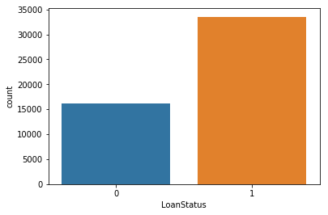

```python
sb.countplot(df_historic["LoanStatus"]);
```

```python
df_historical["LoanStatus"].mean()
```

```
0.6743222588689567
```

So 67% of loans are actually completed, leaving the other 32% defaulted

## Bivariate Exploration

> In this section, investigate relationships between pairs of variables in your data. Make sure the variables that you cover here have been introduced in some fashion in the previous section (univariate exploration).

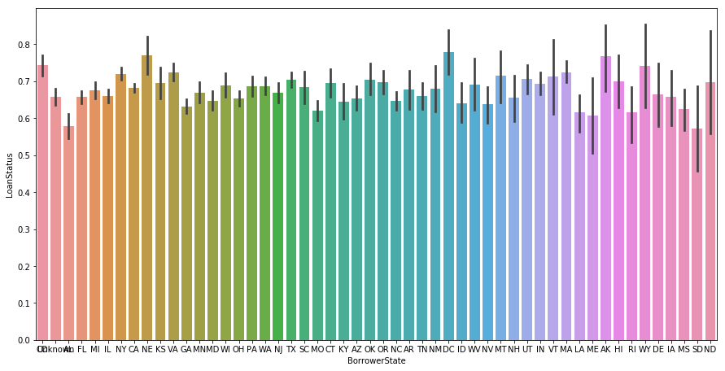

```python
sb.set_context({"figure.figsize": (15, 7.5)})
sb.barplot(x="BorrowerState", y="LoanStatus", data=df_historic);
```

```python
al, dc = df_historical[df_historical["BorrowerState"] == "AL"], df_historical[df_historical["BorrowerState"] == "DC"]

1 - al["LoanStatus"].mean(), 1 - dc["LoanStatus"].mean()
```

```
(0.42205323193916355, 0.22043010752688175)
```

```python
df_historic.replace(to_replace={"ListingCategory (numeric)": {0: "Unknown", 1: "Debt", 2: "Reno", 3: "Business", 4: "Personal",
                                                                5: "Student", 6: "Auto", 7: "Other", 8: "Baby", 9: "Boat",
                                                                10: "Cosmetic", 11: "Engagement", 12: "Green", 13: "Household",
                                                                14: "LargePurchase", 15: "Medical", 16: "Motorcycle", 17: "RV",
                                                                18: "Taxes", 19: "Vacation", 20: "Wedding"}}, inplace=True)

df_historic.rename(index=str, columns={"ListingCategory (numeric)": "ListingCategory"}, inplace=True)

df_historic["ListingCategory"][:10]
```

```
0       Unknown
11      Unknown
12         Debt
15    Household
21      Unknown
23      Medical
26         Debt
27         Debt
30      Wedding
33        Other
Name: ListingCategory, dtype: object
```

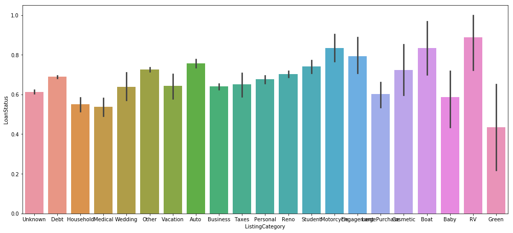

```python
sb.set_context({"figure.figsize": (17, 7.5)})
sb.barplot(x="ListingCategory", y="LoanStatus", data=df_historic);
```

Lets look a the credit scores

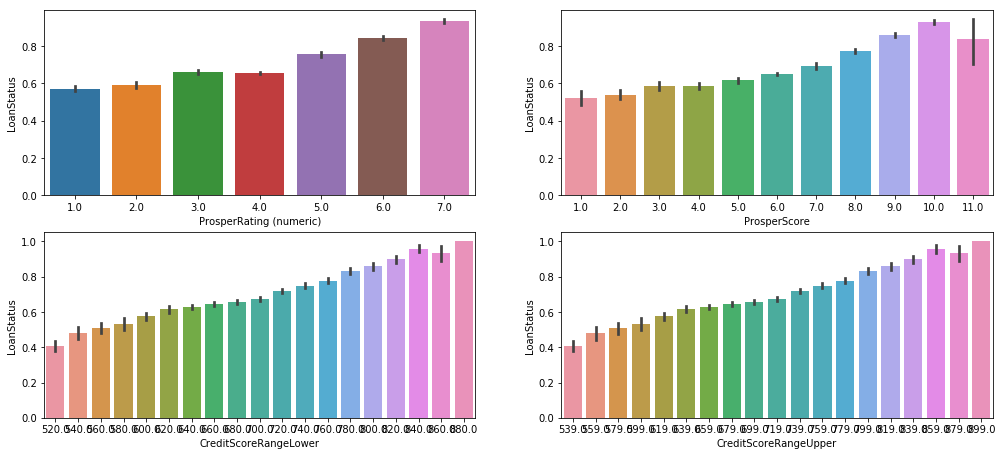

```python
fig = plt.figure()

ax1 = fig.add_subplot(221)
sb.barplot(x="ProsperRating (numeric)", y="LoanStatus", data=df_historic)

ax2 = fig.add_subplot(222)
sb.barplot(x="ProsperScore", y="LoanStatus", data=df_historic)

ax3 = fig.add_subplot(223)
sb.barplot(x="CreditScoreRangeLower", y="LoanStatus", data=df_historic)

ax4 = fig.add_subplot(224)
sb.barplot(x="CreditScoreRangeUpper", y="LoanStatus", data=df_historic)
```

so higher score means lower default rate

quick look at interest rates

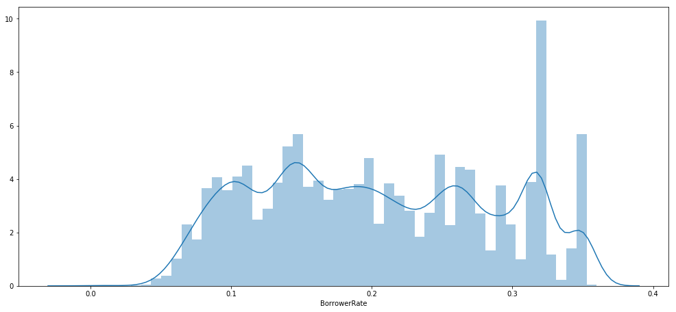

```python
sb.distplot(df_historic["BorrowerRate"])
```

so lets compare rate, default status, and credit score

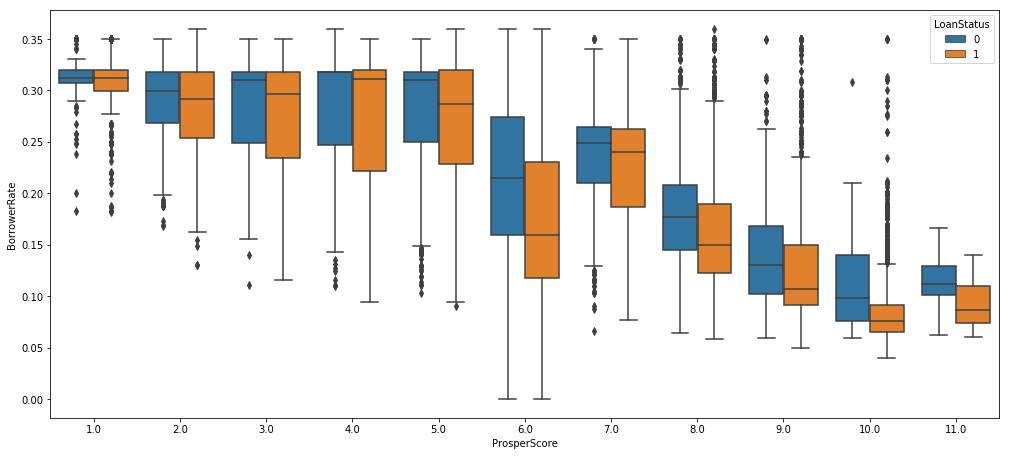

```python
sb.boxplot(x="ProsperScore", y='BorrowerRate', hue='LoanStatus', data=df_historic)
```

so this sort of says higher score gets you a better rate